# Iris clustering

Juan M. Carrillo

September 12, 2018

# Objective

The main objective is to create an interactive `shiny` application.

I decide to let the user cluster a dataset into different groups according to the characteristics of its features.

The dataset to cluster will be the ubiquitous `iris` dataset since probably the user is familiarized with it.

The user will be presented with four different inputs:

On the side panel:

- Number of clusters: From 2 to 10 the user will decide how many groups the data set will be clustered in.
- X axis: The plot generated will use the x-axis chosen by the user.
- Y axis: The plot will use the y-axis selected.

On the main panel:

- By dragging the pointer on the generated plot, the user will be able to select any point.

# Output

Two will be the elements shown as a output on the main panel:

- A plot with the axis selected by the user and each case represented and colored by its cluster and the centroid of the cluster.
- A table with information from the `iris` dataset of the selected points.

# Main plot

Each case is assigned to a cluster using the `kmeans` function from the `stat` package.

The user should see a plot similar to the following one:

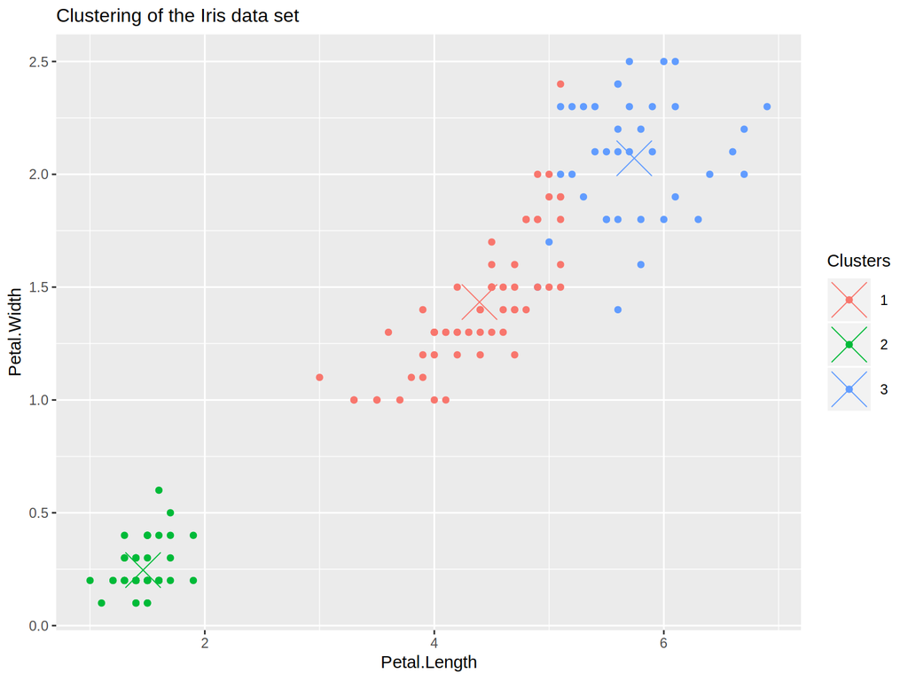